## * 3-RECONSTRUCTION OF LINEAGE PROGRESSION *

Type 'help CALISTA_transition_main' in the command window for more information.

During the lineage inference step for time series Drop-seq data, CALISTA automatically generates and displays a lineage graph, obtained by calculating the shortest path between each cluster at the final cluster progression time and the starting cluster. The inferred lineage is represented by a tree-based graph:

```matlab
[Results]=CALISTA_transition_main(DATA,INPUTS,Results);
```

CALISTA_transition is running...

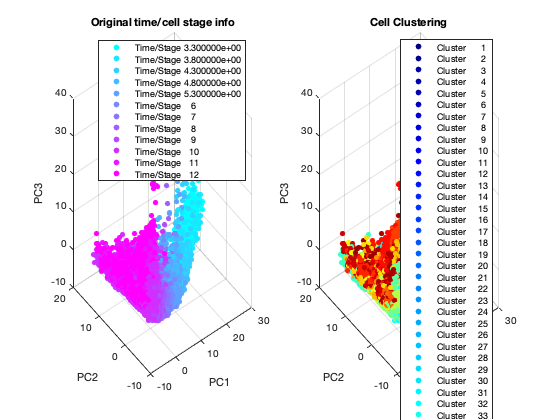

Conditional transition activated...

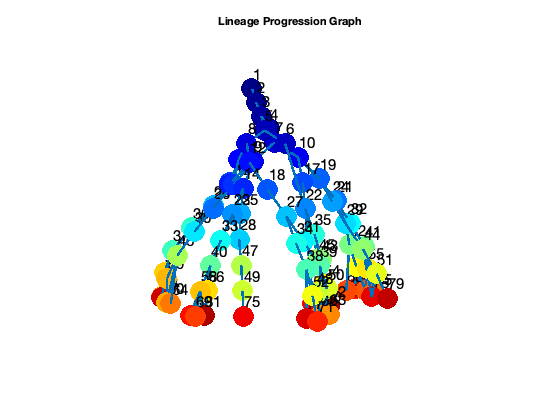

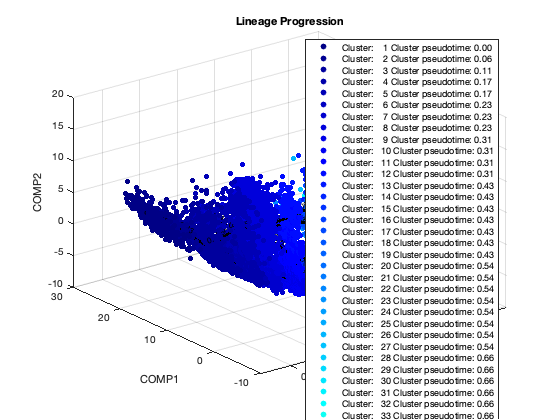

DONE.

```matlab
% % Save 3D video
% figure(100)
% % daspect([2,2,0.3]);
% OptionZ.FrameRate=20;OptionZ.Duration=20.5;OptionZ.Periodic=true;
% CaptureFigVid([-20,10;-110,10;-190,80;-290,10;-380,10], 'CALISTA_lineage_3Dvideo',OptionZ)
```

Here, we do not need to remove any spurious edges, and hence we enter 0 upon queried.

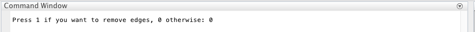

## * 4-DETERMINATION OF TRANSITION GENES *

Type 'help CALISTA_transition_genes_main' in the command window for more information.

After reconstructing the lineage progression, we identify the key transition genes for any two connected clusters in the graph, based on the gene-wise likelihood difference between having the cells separately as two clusters and together as a single cluster. Larger differences in the gene-wise likelihood point to more informative genes. The transition genes are selected as those whose gene-wise likelihood differences make up to more than a certain percentage of the cumulative sum of the likelihood differences of all genes – set by INPUTS.thr_transition_genes.

```matlab
[Results]=CALISTA_transition_genes_main(DATA,INPUTS,Results);
```

CALISTA_transition_genes is running... DONE.

## * 5-PSEUDOTEMPORAL ORDERING OF CELLS *

Type 'help CALISTA_ordering_main' in the command window for more information.

For pseudotemporal ordering of cells, CALISTA performs maximum likelihood optimization for each cell using a linear interpolation of the cell likelihoods between any two connected clusters. The pseudotimes of the cells are computed by linear interpolation of the cluster pseudotimes, and correspond to the maximum point of the likelihood optimization above. Cells are subsequently assigned to the edges in the lineage progression graph. The following screenshot gives the results of this cell-to-edge assignment.

```matlab
[Results]=CALISTA_ordering_main_2(DATA,INPUTS,Results);
```

CALISTA_ordering is running...

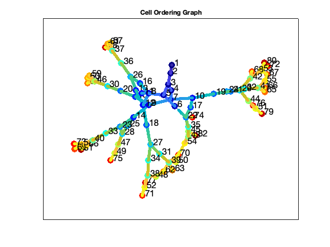

Waiting for plots...

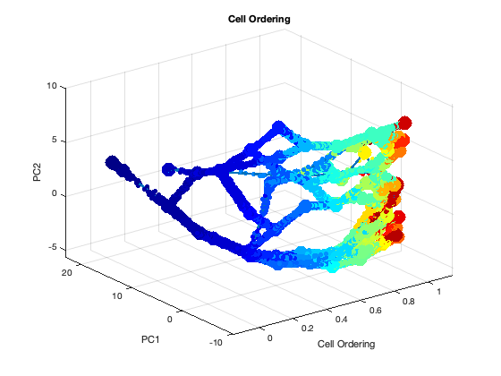

DONE.

```matlab
% [Results_transition_genes]=CALISTA_ordering_main_2_transition_genes(DATA,INPUTS,Results);
```

## * 7-PATH ANALYSIS *

Type 'help CALISTA_path_main' in the command window for more information.

To plot the expression of marker genes along each path, users can enter 1 upon queried and load the excel file containing the list of genes if interest. In this case the file is in EXAMPLES/FARRELL:

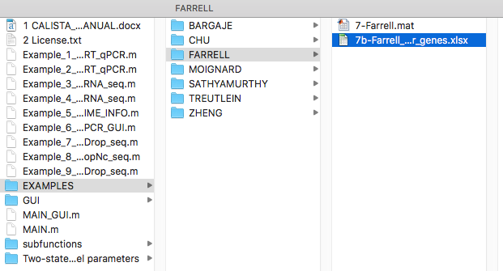

```matlab
Proceed2=input(' Press 1 if you want to select transition paths and perform additional analysis, 0 otherwise: ');

if ~Proceed2
    return
end

[FileName,PathName,FilterIndex] = uigetfile('*.*');
filename=strcat(PathName, FileName);
selected_genes=importdata(filename);

Results=CALISTA_path_main(DATA,INPUTS,Results,'selected_genes',selected_genes);
```

Automatically detect paths along the graph based on shortestpath..

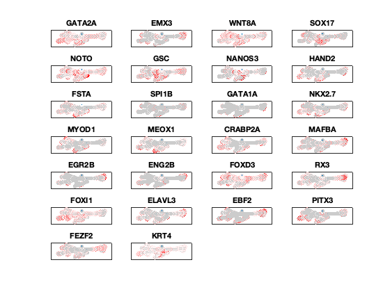

DONE.

```matlab
% % check final cell types
% [FileName,PathName,FilterIndex] = uigetfile('*.*');
% filename=strcat(PathName, FileName);
% metadata=importdata(filename);
% metadata(DATA.cut_sort.idx2cutCELL,:)=[];
% metadata=metadata(DATA.cut_sort.idx_sorted_cells,:);
%
% [FileName,PathName,FilterIndex] = uigetfile('*.*');
% filename=strcat(PathName, FileName);
% lineage=importdata(filename);
%
% metadata2=metadata(find(DATA.timeline==max(DATA.timeline)),:);
%
```